# LanguageExperimentAnalysis

Jordi Ren

20th Aug 2025

# Library loading

```r
library(xlsx)
library(dplyr)
library(ggplot2)
```

# Data reading

```r
data <- read.xlsx("data/results_false.xlsx", sheetIndex = 1)
factor_cols <- c("subject", "session", "language", "sex",
                 "test.category", "test.number", "trial")
data[factor_cols] <- lapply(data[factor_cols], as.factor)
data$ACC <- as.numeric(data$ACC)
str(data)
```

```
## 'data.frame':    14900 obs. of  10 variables:
##  $ subject      : Factor w/ 149 levels "2","3","4","5",..: 1 1 1 1 1 1 1 1 1 1 ...
##  $ session      : Factor w/ 2 levels "1","2": 1 1 1 1 1 1 1 1 1 1 ...
##  $ language     : Factor w/ 3 levels "Bilingual","Chinese",..: 2 2 2 2 2 2 2 2 2 2 ...
##  $ age          : num  24 24 24 24 24 24 24 24 24 24 ...
##  $ sex          : Factor w/ 3 levels "female","female ",..: 1 1 1 1 1 1 1 1 1 1 ...
##  $ ACC          : num  1 1 1 1 1 1 0 0 1 1 ...
##  $ RT           : num  3213 3377 2990 3703 2162 ...
##  $ test.category: Factor w/ 4 levels "A","B","C","D": 1 1 1 1 1 1 2 2 2 2 ...
##  $ test.number  : Factor w/ 4 levels "exam","test1",..: 2 2 2 2 2 2 2 2 2 2 ...
##  $ trial        : Factor w/ 7 levels "1","2","3","4",..: 1 2 3 4 5 6 1 2 3 4 ...
```

After reading the data, some columns are set to factors so that we can work with them with more ease afterwards.

You will also notice that there are 3 categories in the variable *sex*, as some registries contain an empty space after the word *“female”*. We will fix this little issue first.

```r
data$sex[which(data$sex == "female ")] <- "female"
data$sex <- factor(data$sex)
summary(data)
```

```
##     subject      session       language         age            sex
##  2      :  100   1:7400   Bilingual:5000   Min.   :18.00   female:8900
##  3      :  100   2:7500   Chinese  :4900   1st Qu.:22.00   male  :6000
##  4      :  100            Spanish  :5000   Median :24.00
##  5      :  100                             Mean   :23.79
##  6      :  100                             3rd Qu.:26.00
##  7      :  100                             Max.   :34.00
##  (Other):14300
##       ACC               RT       test.category test.number  trial
##  Min.   :0.0000   Min.   :   0   A:3725        exam :4172   1:2384
##  1st Qu.:1.0000   1st Qu.:1361   B:3725        test1:3576   2:2384
##  Median :1.0000   Median :2029   C:3725        test2:3576   3:2384
##  Mean   :0.7593   Mean   :2470   D:3725        test3:3576   4:2384
##  3rd Qu.:1.0000   3rd Qu.:3168                              5:2384
##  Max.   :1.0000   Max.   :9980                              6:2384
##                                                             7: 596
```

NAs are also checked just in case.

```r
table(is.na(data))
```

```
##
##  FALSE
## 149000
```

# (Initial) Descriptive analysis

Here, we will first create a summarized data frame to get some averaged data per subject so we can have a general idea of our data through some descriptive plots.

```r
subject_info <- data %>%
  group_by(subject) %>%
  summarise(
    session  = first(session),
    language = first(language),
    age      = first(age),
    sex      = first(sex),
    ACC      = sum(ACC),
    .groups = "drop"
  )
```

## Age distribution

We will start checking the distribution of the age of the subjects.

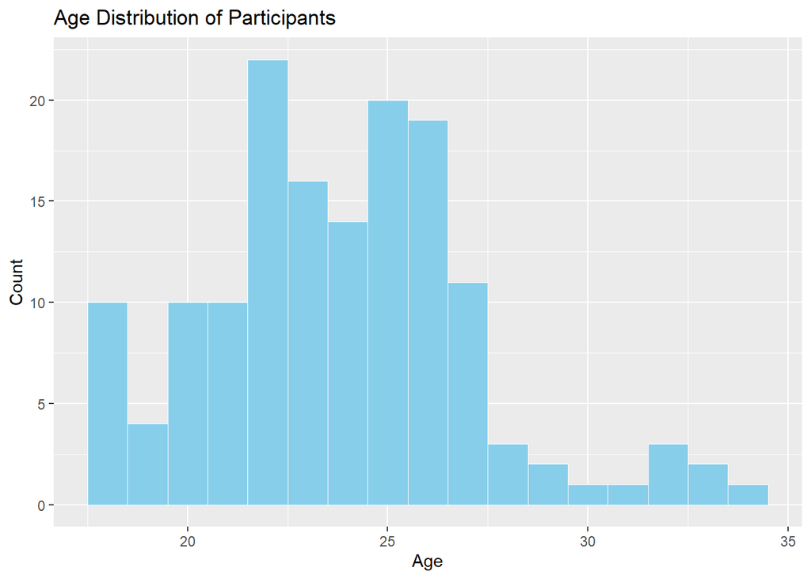

```r
ggplot(subject_info, aes(x = age)) +
  geom_histogram(binwidth = 1, fill = "skyblue",
                 color = "white", linewidth = 0.2) +
  labs(title = "Age Distribution of Participants",
       x = "Age", y = "Count")
```

It could also be interesting to see the distribution per language group:

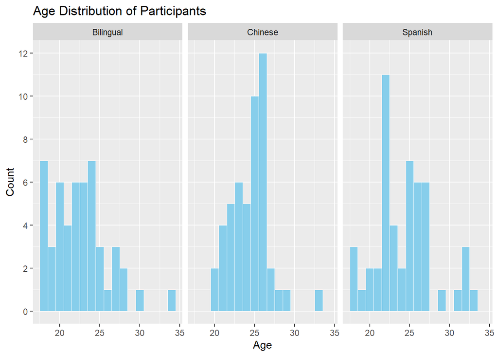

```r
ggplot(subject_info, aes(x = age)) +
  geom_histogram(binwidth = 1, fill = "skyblue",
                 color = "white", linewidth = 0.2) +
  facet_wrap(~ language) +
  scale_y_continuous(limits = c(0, 12), breaks = seq(0, 12, 2)) +
  labs(title = "Age Distribution of Participants",
       x = "Age", y = "Count")
```

## Sex distribution

Here we will also plot the overall proportion as well as per language groups.

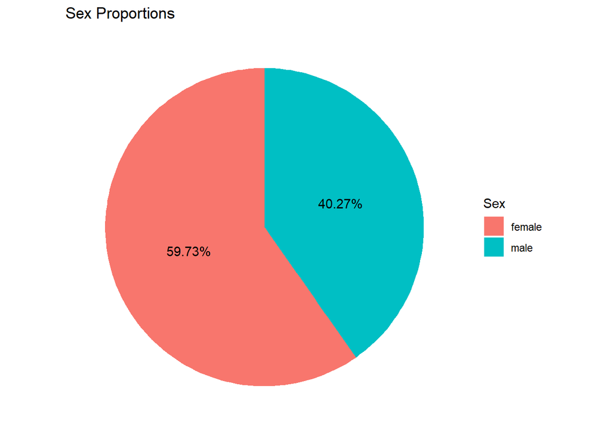

```r
sex_counts <- subject_info %>%
  count(sex) %>%
  mutate(percentage = n / sum(n) * 100)

ggplot(sex_counts, aes(x = "", y = percentage, fill = sex)) +
  geom_col(width = 1) +
  coord_polar(theta = "y") +
  labs(title = "Sex Proportions", fill = "Sex",
       x = NULL, y = NULL) +
  theme_minimal() +
  theme(panel.background = element_rect(fill = "white", color = NA),
        plot.background = element_rect(fill = "white", color = NA),
        axis.text = element_blank(),
        axis.ticks = element_blank(),
        panel.grid = element_blank()) +
  geom_text(aes(label = paste0(round(percentage, 2), "%")),
            position = position_stack(vjust = 0.5))
```

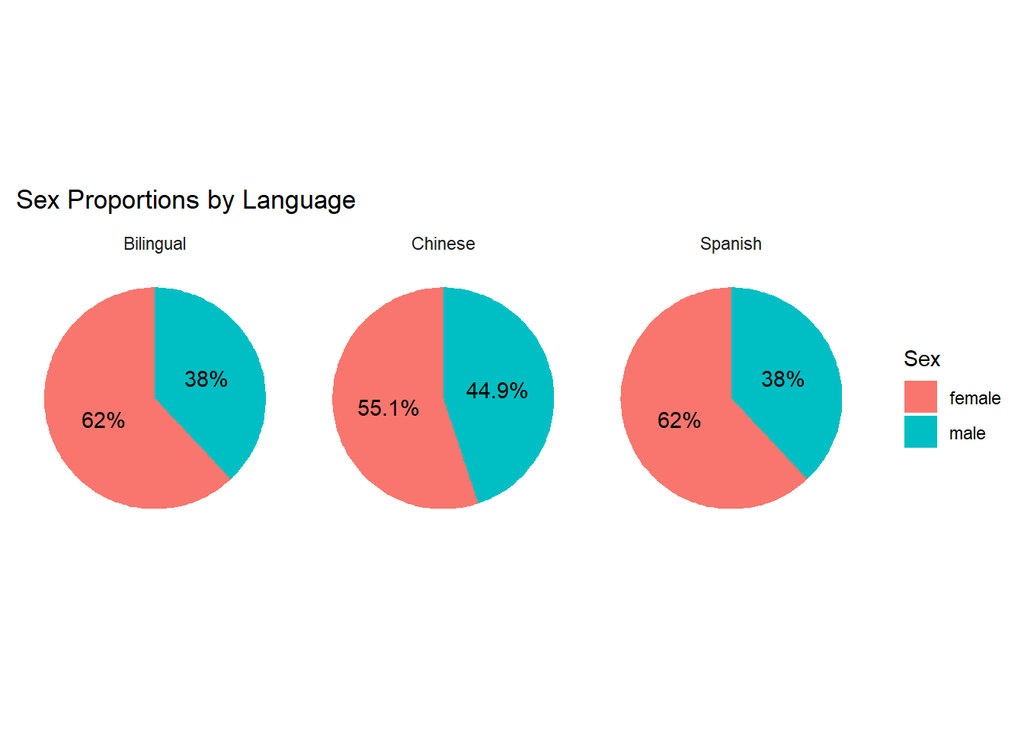

```r
sex_counts <- subject_info %>%
  count(language, sex) %>%
  group_by(language) %>%
  mutate(percentage = n / sum(n) * 100)

ggplot(sex_counts, aes(x = "", y = percentage, fill = sex)) +
  geom_col(width = 1) +
  coord_polar(theta = "y") +
  facet_wrap(~ language) +
  labs(title = "Sex Proportions by Language", fill = "Sex",
       x = NULL, y = NULL) +
  theme_minimal() +
  theme(panel.background = element_rect(fill = "white", color = NA),
        plot.background = element_rect(fill = "white", color = NA),
        axis.text = element_blank(),
        axis.ticks = element_blank(),
        panel.grid = element_blank()) +
  geom_text(aes(label = paste0(round(percentage, 2), "%")),
            position = position_stack(vjust = 0.5))
```

## Accuracy per Language group

To have a general idea of the overall ACC reached by the subjects per language group, we will plot a boxplot. The boxes highlight where the middle half of the values lie, with the line inside marking the typical (median) value. The “whiskers” extend to the usual minimum and maximum, while any dots beyond them show unusually high or low values.

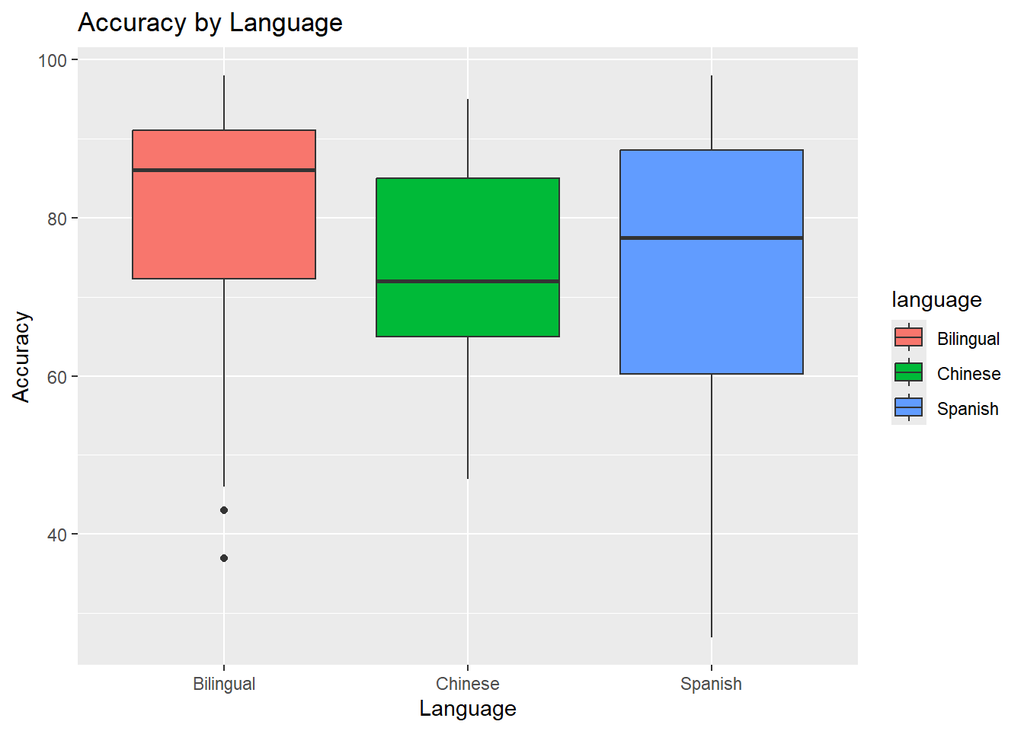

```r
subject_info %>%
  group_by(language, subject) %>%
  summarise(acc = sum(ACC, na.rm = TRUE)) %>%
  ggplot(aes(x = language, y = acc, fill = language)) +
  geom_boxplot() +
  labs(title = "Accuracy by Language",
       x = "Language",
       y = "Accuracy")
```

## ACC by sex and language

To have a general idea of whether there are differences or not in ACC between sex categories, we plot the mean ACC among subjects per sex and split them per Language group:

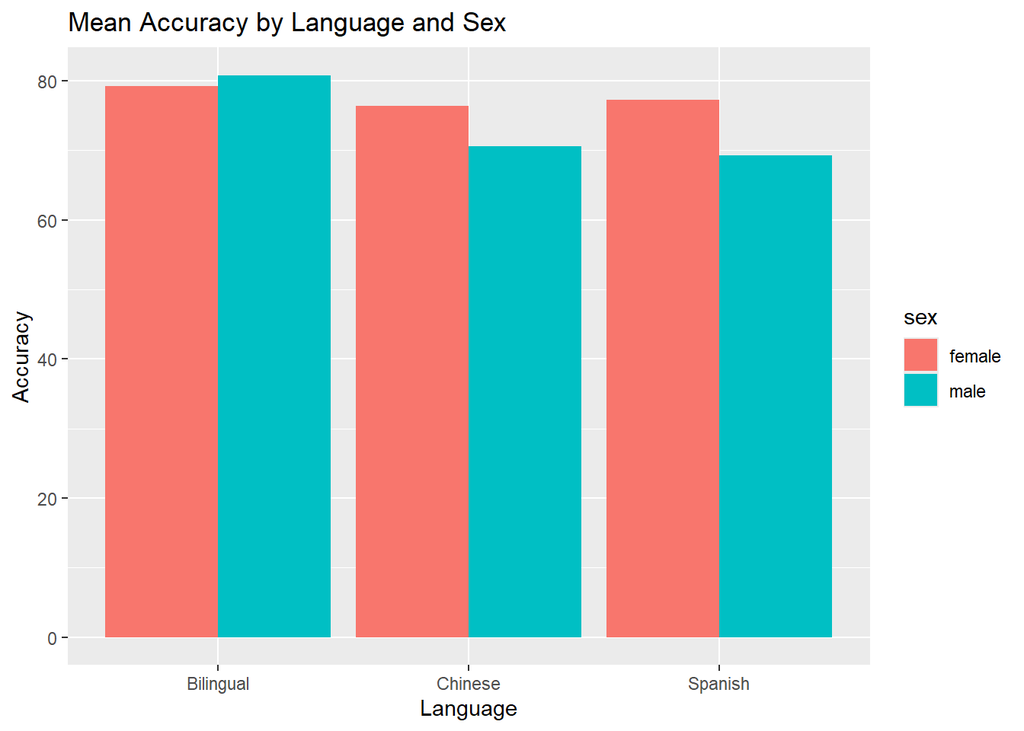

```r
subject_info %>%
  group_by(language, sex) %>%
  summarise(acc = mean(ACC, na.rm = TRUE)) %>%
  ggplot(aes(x = language, y = acc, fill = sex)) +
  geom_col(position = "dodge") +
  labs(title = "Mean Accuracy by Language and Sex",
       x = "Language",
       y = "Accuracy")
```

## Accuracy over Test

The following scatterplot helps us to observe the evolution of the mean ACC among subjects per Language class throught the different tests:

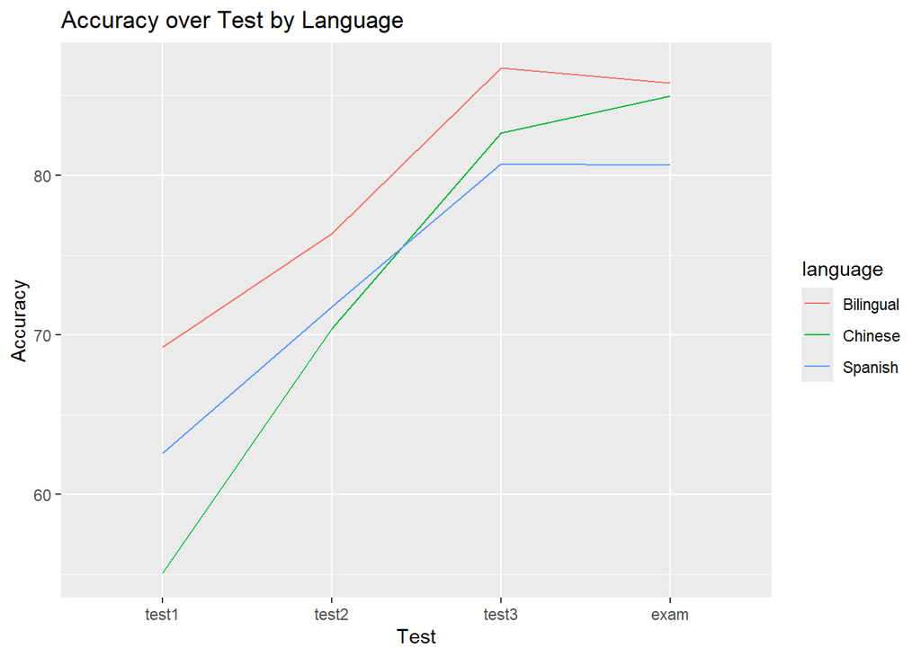

```r
data <- data %>%
  mutate(test.number = factor(test.number,
                              levels = c("test1", "test2",
                                         "test3", "exam")))
data %>%
  group_by(test.number, language) %>%
  summarise(acc = mean(ACC*100, na.rm = TRUE)) %>%
  ggplot(aes(x = test.number, y = acc,
             group = language, color = language)) +
    stat_summary(fun = mean, geom = "line") +
    labs(title = "Accuracy over Test by Language",
         x = "Test",
         y = "Accuracy")
```

## Reaction Time per Language group

Similar to the previous boxplot, he we will see how are distributed the Reaction Times (RT).

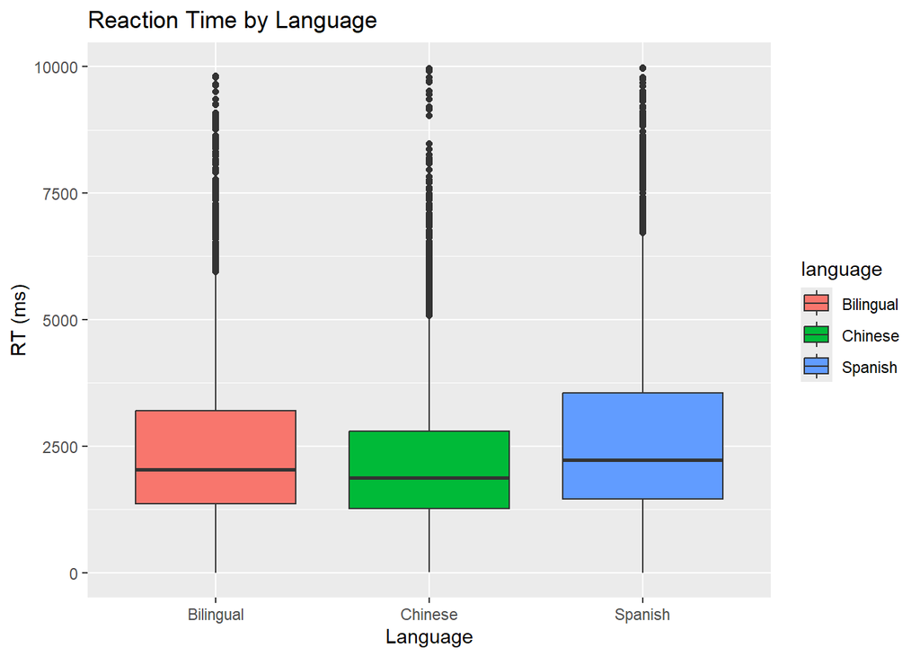

```r
ggplot(data, aes(x = language, y = RT, fill = language)) +
  geom_boxplot() +
  labs(title = "Reaction Time by Language",
       x = "Language",
       y = "RT (ms)")
```

Here, it could be more interesting to see the RT per test though:

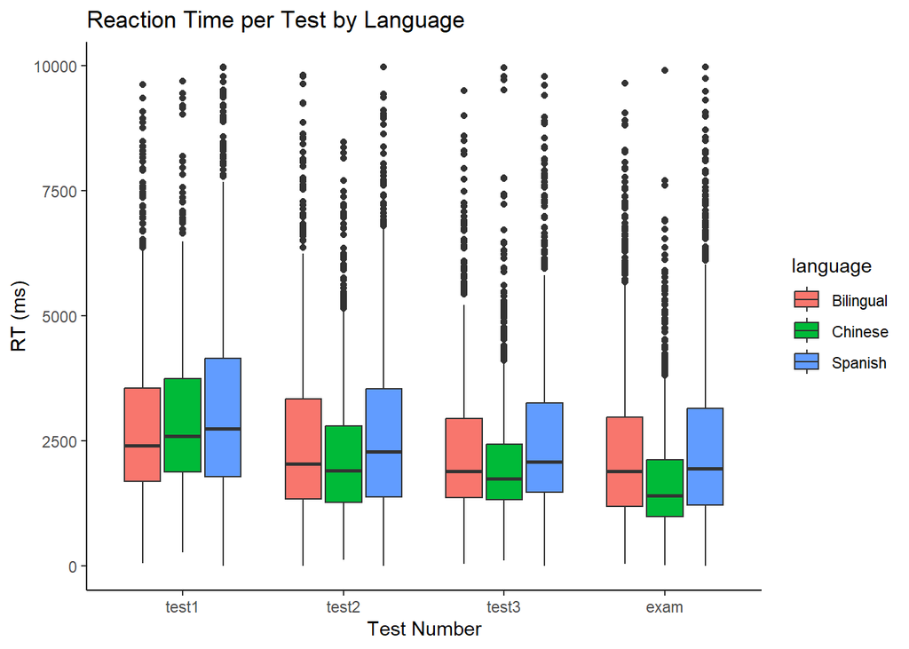

```r
ggplot(data, aes(x = test.number, y = RT, fill = language)) +
  geom_boxplot() +
  labs(title = "Reaction Time per Test by Language",
       x = "Test Number",
       y = "RT (ms)") +
  theme_classic()
```

So, as we expected, RTs are higher mainly in **Test1**, while it seems quite similar for the remaining tests and exam.

## RT distribution

To observe the real distribution of the reaction times, we will use histograms. This will also give some valuable insights for the ANOVA tests that we will perform later.

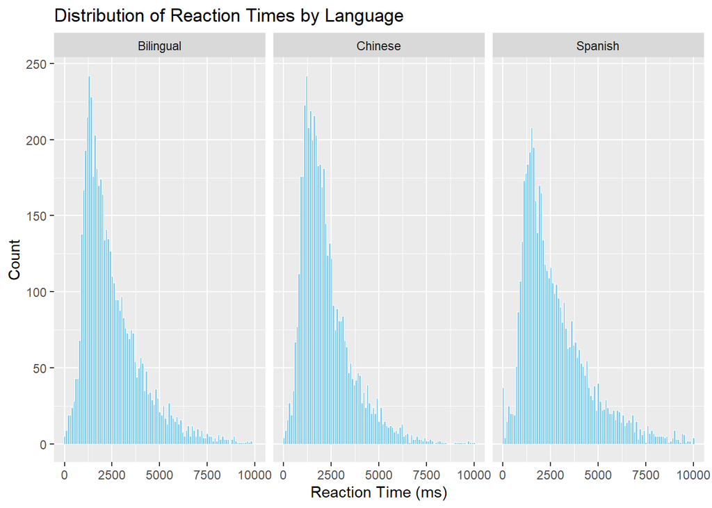

```r
ggplot(data, aes(x = RT)) +
  geom_histogram(binwidth = 100, fill = "skyblue",
                 color = "white", linewidth = 0.2) +
  facet_wrap(~ language) +
  labs(title = "Distribution of Reaction Times by Language",
       x = "Reaction Time (ms)",
       y = "Count")
```

# ANOVA

ANOVA, short for *Analysis of Variance*, is a statistical method used to compare the averages of several groups at once. Instead of checking only two groups (like in a t-test), ANOVA can test three or more groups to see if at least one of them has a different average. It works by comparing the variation within each group to the variation between groups. If the differences between groups are much larger than the differences inside the groups, ANOVA concludes that not all group means are the same. In simple terms, ANOVA helps answer the question: *“Are these groups really different, or could the differences just be due to random chance?”*

For this test to give reliable results, the data has to meet some conditions:

1. The groups being compared should be independent of each other (here we will asume it’s true due to the experimental design).
2. The values inside each group should roughly follow a normal distribution (bell-shaped).
3. The groups should have similar levels of variation (homogeneity of variances or **homoscedasticity**).

If these conditions are not met, the conclusions from ANOVA may be misleading.

Here we will start by building the different data frames with the data per subject that we want to contrast:

```r
ACC_per_subj <- data %>%
  group_by(subject) %>%
  summarise(language = first(language),
            ACC = sum(ACC),
            .groups = "drop"
            ) %>%
  select(-subject)

RT_per_subj <- data %>%
  group_by(subject) %>%
  summarise(language = first(language),
            RT = mean(RT),
            .groups = "drop"
            ) %>%
  select(-subject)

RT_test1 <- data %>%
  filter(test.number == "test1") %>%
  group_by(subject, test.number) %>%
  summarise(language = first(language),
            RT = mean(RT),
            .groups = "drop"
            ) %>%
  select(-c(subject, test.number))

RT_test2 <- data %>%
  filter(test.number == "test2") %>%
  group_by(subject, test.number) %>%
  summarise(language = first(language),
            RT = mean(RT),
            .groups = "drop"
            ) %>%
  select(-c(subject, test.number))

RT_test3 <- data %>%
  filter(test.number == "test3") %>%
  group_by(subject, test.number) %>%
  summarise(language = first(language),
            RT = mean(RT),
            .groups = "drop"
            ) %>%
  select(-c(subject, test.number))

RT_exam <- data %>%
  filter(test.number == "exam") %>%
  group_by(subject, test.number) %>%
  summarise(language = first(language),
            RT = mean(RT),
            .groups = "drop"
            ) %>%
  select(-c(subject, test.number))
```

To have a quick glance of how does the data look like:

```r
summary(ACC_per_subj)
```

```
##       language       ACC
##  Bilingual:50   Min.   :27.00
##  Chinese  :49   1st Qu.:65.00
##  Spanish  :50   Median :78.00
##                 Mean   :75.93
##                 3rd Qu.:88.00
##                 Max.   :98.00
```

```r
summary(RT_per_subj)
```

```
##       language        RT
##  Bilingual:50   Min.   :1005
##  Chinese  :49   1st Qu.:1963
##  Spanish  :50   Median :2527
##                 Mean   :2470
##                 3rd Qu.:2883
##                 Max.   :4080
```

```r
summary(RT_test1)
```

```
##       language        RT
##  Bilingual:50   Min.   :1426
##  Chinese  :49   1st Qu.:2337
##  Spanish  :50   Median :2926
##                 Mean   :2978
##                 3rd Qu.:3489
##                 Max.   :5209
```

But still, the questions to answer is quite unclear:  
- **What do we want to compare?**  
- **Which effects do we want to take into account?**  
- How many fixed effects? (Only language? Or Lang + Test?)  
- Effects of interactions are taken into account if we do ANOVA of 2 or more factors?